# W4: Start with R

##Exercise 1: Use R to figure out how many elements in the vector below are greater than 2 . (You need to filter out the NAs first) rooms <- c(1, 2, 1, 3, 1, NA, 3, 1, 3, 2, 1, NA, 1, 8, 3, 1, 4, NA, 1, 3, 1, 2, 1, 7, 1, NA)

```r
#create object
rooms <- c(1, 2, 1, 3, 1, NA, 3, 1, 3, 2, 1, NA, 1, 8, 3, 1, 4, NA, 1, 3, 1, 2, 1, 7, 1, NA)

#remove na's
rooms_clean <- na.omit(rooms)
rooms_clean
```

```
##  [1] 1 2 1 3 1 3 1 3 2 1 1 8 3 1 4 1 3 1 2 1 7 1
## attr(,"na.action")
## [1]  6 12 18 26
## attr(,"class")
## [1] "omit"
```

```r
#count how many elements are greater than 2
sum(rooms_clean > 2)
```

```
## [1] 8
```

##Exercise 2: What is the result of running median() function on the above ‘rooms’ vector? (again, best remove the NAs)

```r
#apply median function
median(rooms_clean)
```

```
## [1] 1.5
```

The median() function on the “rooms” vector (or in my case rooms_clean, which has no NA’s) gives 1.5.

##Exercise 3: Inside your R Project (.Rproj), install the ‘tidyverse’ package and use the download.file() and read_csv() function to read the SAFI_clean.csv dataset into your R project as ‘interviews’ digital object (see instructions in https://datacarpentry.org/r-socialsci/setup.html and ‘Starting with Data’ section). Take a screenshot of your RStudio interface showing a) the script you used to create the object, b) the ‘interviews’ object in the Environment and the c) structure of your R project in the bottom right Files pane. Save the screenshot as an image and put it in your AUID_lastname_firstname repository inside our Github organisation (github.com/Digital-Methods-HASS). Place here the URL leading to the screenshot in your repository.

```r
library(tidyverse)
```

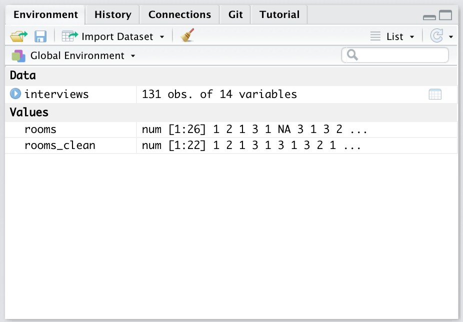

[figure not shown]

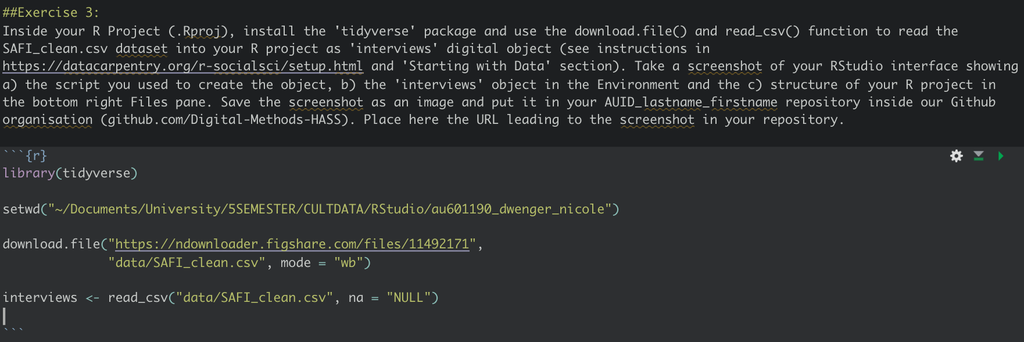

```r
setwd("~/Documents/University/5SEMESTER/CULTDATA/RStudio/au601190_dwenger_nicole")

download.file("https://ndownloader.figshare.com/files/11492171",
              "data/SAFI_clean.csv", mode = "wb")

interviews <- read_csv("data/SAFI_clean.csv", na = "NULL")
```